# Mapping vegetation and weeds with artificial neural networks

First, let's install the raster and connect the Drive:

```python
!pip install rasterio
```

```
Downloading rasterio-1.3.10-cp310-cp310-manylinux2014_x86_64.whl (21.5 MB)
   ━━━━━━━━━━━━━━━━━━━━━━━━━━━━━━━━━━━━━━━━ 21.5/21.5 MB 24.6 MB/s eta 0:00:00
Downloading snuggs-1.4.7-py3-none-any.whl (5.4 kB)
Downloading affine-2.4.0-py3-none-any.whl (15 kB)
```

```python
from google.colab import drive
drive.mount('/content/drive')
```

Now, let's import the libraries:

```python
import os
import cv2
import matplotlib.pyplot as plt
import numpy as np
import rasterio
from rasterio.windows import Window
import pandas as pd
import geopandas as gpd
from pylab import rcParams
import matplotlib
rcParams['figure.figsize'] = 18, 16
from sklearn.model_selection import train_test_split
from rasterio.plot import show
from shapely.geometry import box
import seaborn as sns
```

The image and shape files to be used are stored in Drive. A point file was collected for each class we have.

```python
path_img = '/content/drive/MyDrive/Datasets/Pinas/AOI_img.tif'
path_classe1 = '/content/drive/MyDrive/Datasets/Pinas/Solo.shp'
path_classe2 = '/content/drive/MyDrive/Datasets/Pinas/Veg.shp'
path_classe3 = '/content/drive/MyDrive/Datasets/Pinas/Invasoras.shp'
```

```python
gdf1 = gpd.read_file(path_classe1)
gdf2 = gpd.read_file(path_classe2)
gdf3 = gpd.read_file(path_classe3)
```

```python
fig, ax = plt.subplots(figsize=(20, 20))
with rasterio.open(path_img) as src:
    gdf1 = gdf1.to_crs(src.crs.to_dict())
    gdf2 = gdf2.to_crs(src.crs.to_dict())
    gdf3 = gdf3.to_crs(src.crs.to_dict())
    show(src,ax=ax)
gdf1.plot(ax=ax, color='red')
gdf2.plot(ax=ax, color='green')
gdf3.plot(ax=ax, color='yellow')
```

[output not shown]

Now we add an id to each of the classes:

```python
gdf1['id'] = 0
gdf2['id'] = 1
gdf3['id'] = 2
```

Let's concatenate the point geodataframes and extract the spectral values of the image at each point:

```python
gdf = pd.concat([gdf1,gdf2,gdf3], axis=0)
```

```python
gdf
```

|  | id | geometry |
| --- | --- | --- |
| 0 | 0 | POINT (800522.754 1148937.597) |
| 1 | 0 | POINT (800541.974 1148936.659) |
| 2 | 0 | POINT (800559.084 1148935.253) |
| 3 | 0 | POINT (800579.593 1148934.315) |
| 4 | 0 | POINT (800509.628 1148938.182) |
| ... | ... | ... |
| 147 | 2 | POINT (800469.285 1148898.636) |
| 148 | 2 | POINT (800469.285 1148898.375) |
| 149 | 2 | POINT (800469.629 1148897.139) |
| 150 | 2 | POINT (800470.038 1148896.720) |
| 151 | 2 | POINT (800470.503 1148896.274) |

431 rows × 2 columns

```python
coord_list = [(x, y) for x, y in zip(gdf.geometry.x, gdf.geometry.y)]
```

```python
Values_list = []
Column_list = []
with rasterio.open(path_img) as src:
  Values = [x for x in src.sample(coord_list)]
  Values_list.append(Values)
```

```python
X = np.array(Values_list)
X = X[0].copy()
X = X[:,0:3].copy()
```

```python
X.shape
```

```
(431, 3)
```

We have the variable X with the spectral data and the variable Y with the reference data:

```python
Y = gdf['id'].values
Y = Y[:,np.newaxis]
```

```python
Y
```

```
array([[0],
       [0],
       [0],
       [0],
       [0],
       [0],
       [0],
       [0],
       [0],
       [0],
       [0],
       [0],
       [0],
       [0],
       [0],
       [0],
       [0],
       [0],
       [0],
       [0],
       [0],
       [0],
       [0],
       [0],
       [0],
       [0],
       [0],
       [0],
       [0],
       [0],
       [0],
       [0],
       [0],
       [0],
       [0],
       [0],
       [0],
       [0],
       [0],
       [0],
```

[output cut: 376 more lines]

```
       [2],
       [2],
       [2],
       [2],
       [2],
       [2],
       [2],
       [2],
       [2],
       [2],
       [2],
       [2],
       [2],
       [2],
       [2]])
```

```python
from sklearn.preprocessing import OneHotEncoder
from sklearn.model_selection import train_test_split
from sklearn.metrics import classification_report
from sklearn.metrics import cohen_kappa_score
from sklearn.metrics import confusion_matrix
```

Since we are working with categorical data, we need to encode categorical values into binary values so that they are compatible with the expected results of a neural network:

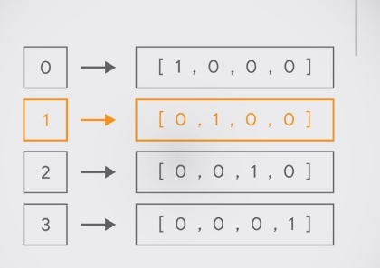

```python
enc = OneHotEncoder()

enc.fit(Y)

Y = enc.transform(Y).toarray()
```

```python
Y.shape
```

```
(431, 3)
```

So, we split the data into training and testing:

```python
X_train, X_test, Y_train, Y_test = train_test_split(X, Y, test_size = 0.3, random_state = 42)
```

```python
input_shape = (X_train.shape[1:])
num_classes = len(np.unique(gdf['id'].values))
```

```python
input_shape
```

```
(3,)
```

```python
num_classes
```

```
3
```

Let's build our neural network by adding the dense layers:

```python
from tensorflow import keras
from tensorflow.keras.models import Sequential
from tensorflow.keras.layers import Dense
```

```python
model = Sequential()
model.add(Dense(256, input_shape=input_shape, activation='relu'))
model.add(Dense(128, activation='relu'))
model.add(Dense(64, activation='relu'))
model.add(Dense(8, activation='relu'))
model.add(Dense(num_classes, activation='softmax'))
```

```python
model.compile(loss='categorical_crossentropy', optimizer='adam', metrics=['accuracy'])
```

```python
model.summary()
```

[output not shown]

And finally, train the model for 400 iterations:

```python
history = model.fit(X_train, Y_train, epochs=400, batch_size=250, verbose=1, validation_split=0.25)
```

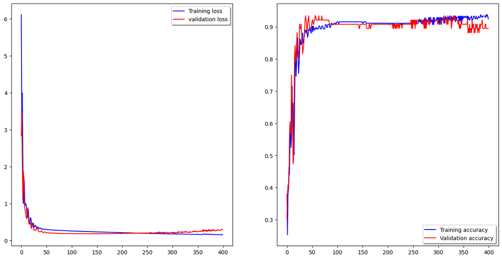

```python
fig, ax = plt.subplots(1,2, figsize=(16,8))
ax[0].plot(history.history['loss'], color='b', label="Training loss")
ax[0].plot(history.history['val_loss'], color='r', label="validation loss",axes =ax[0])
legend = ax[0].legend(loc='best', shadow=True)

ax[1].plot(history.history['accuracy'], color='b', label="Training accuracy")
ax[1].plot(history.history['val_accuracy'], color='r',label="Validation accuracy")
legend = ax[1].legend(loc='best', shadow=True)
```

Let's look at some model evaluation metrics:

```python
score = model.evaluate(X_test, Y_test, verbose=0)
print('Test loss:', score[0])
print('Test accuracy:', score[1])
```

```
Test loss: 0.20202559232711792
Test accuracy: 0.9230769276618958
```

```python
y_pred = model.predict(X_test)
```

```python
y_pred_res = np.argmax(y_pred, axis=1)
```

```python
Y_test_res = np.argmax(Y_test, axis=1)
```

```python
print(classification_report(Y_test_res, y_pred_res))
```

```
              precision    recall  f1-score   support

           0       1.00      1.00      1.00        49
           1       0.85      0.89      0.87        38
           2       0.90      0.86      0.88        43

    accuracy                           0.92       130
   macro avg       0.92      0.92      0.92       130
weighted avg       0.92      0.92      0.92       130
```

```python
c_matrix = confusion_matrix(Y_test_res, y_pred_res)
```

```python
names = ['Solo','Vegetação','Daninhas']
```

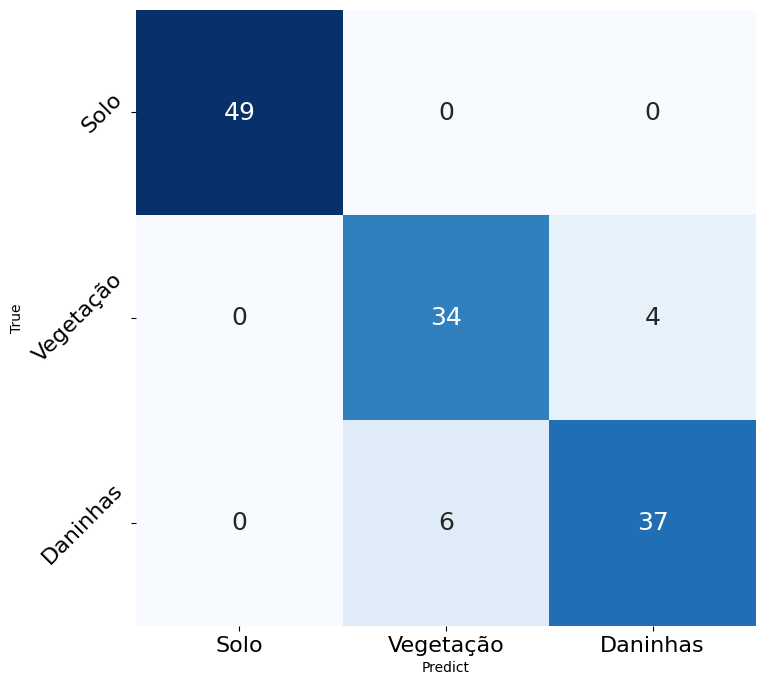

```python
r1 = pd.DataFrame(data=c_matrix, index= names, columns=names)
fig, ax = plt.subplots(figsize=(8,8))
ax = sns.heatmap(r1, annot=True, annot_kws={"size": 18},fmt='d',cmap="Blues", cbar = False)
ax.tick_params(labelsize=16)
ax.set_yticklabels(names, rotation=45)
ax.set_ylabel('True')
ax.set_xlabel('Predict')
```

After training and validating our AI model, we will now apply it to the full image, thus generating a map with the predictions:

```python
src = rasterio.open(path_img)
img = src.read()
```

```python
img = img.transpose([1,2,0])
img_size = (img.shape[0] , img.shape[1])
img = img.reshape(img.shape[0] * img.shape[1], img.shape[2])
```

```python
img.shape
```

```
(51650802, 4)
```

After opening the image, let's create a data frame with the spectral information and the alpha band:

```python
df = pd.DataFrame(img, columns=['R','G','B','Mask'])
```

```python
df
```

|  | R | G | B | Mask |
| --- | --- | --- | --- | --- |
| 0 | 164 | 130 | 109 | 255 |
| 1 | 162 | 128 | 106 | 255 |
| 2 | 161 | 127 | 105 | 255 |
| 3 | 160 | 127 | 106 | 255 |
| 4 | 157 | 124 | 102 | 255 |
| ... | ... | ... | ... | ... |
| 51650797 | 0 | 0 | 0 | 0 |
| 51650798 | 0 | 0 | 0 | 0 |
| 51650799 | 0 | 0 | 0 | 0 |
| 51650800 | 0 | 0 | 0 | 0 |
| 51650801 | 0 | 0 | 0 | 0 |

51650802 rows × 4 columns

```python
del img, src
```

We will remove invalid values using the alpha band:

```python
df_to_pred = df[df['Mask'] == 255].copy()
values_to_pred = df_to_pred.values[:,0:3]
```

```python
df_to_pred.drop(columns={'R', 'G', 'B'}, inplace = True)
df.drop(columns={'R', 'G', 'B'}, inplace = True)
```

Now we apply the model to the values to obtain the predictions:

```python
pred = model.predict(values_to_pred)
```

With the predicted values, we join the entire image dataframe by the index:

```python
pred = np.argmax(pred, axis=1).copy()
df_to_pred['pred'] = pred
```

```python
del pred, values_to_pred, model
```

```python
df = pd.merge(df,df_to_pred, how='left', left_index=True, right_index=True)
```

```python
del df_to_pred
```

So we have the predictions and we can convert them to the original image size:

```python
values_to_export = df['pred'].values
```

```python
del df
```

```python
classify = values_to_export.reshape(img_size)
export_image = classify[np.newaxis,:,:]
```

Finally we save the predicted image data with georeferencing of the RGB image used:

```python
export_image.dtype
```

```
dtype('float64')
```

```python
src = rasterio.open(path_img)
out_meta = src.meta.copy()
out_meta.update({"driver": "GTiff",
                  "height": export_image.shape[1],
                  "width": export_image.shape[2],
                  "compress":'lzw',
                  "nodata": np.nan,
                  "dtype": 'float64',
                  "count":1
                  })
```

```python
with rasterio.open('/content/mapa.tif', "w", **out_meta) as dest:
     dest.write(export_image)
```

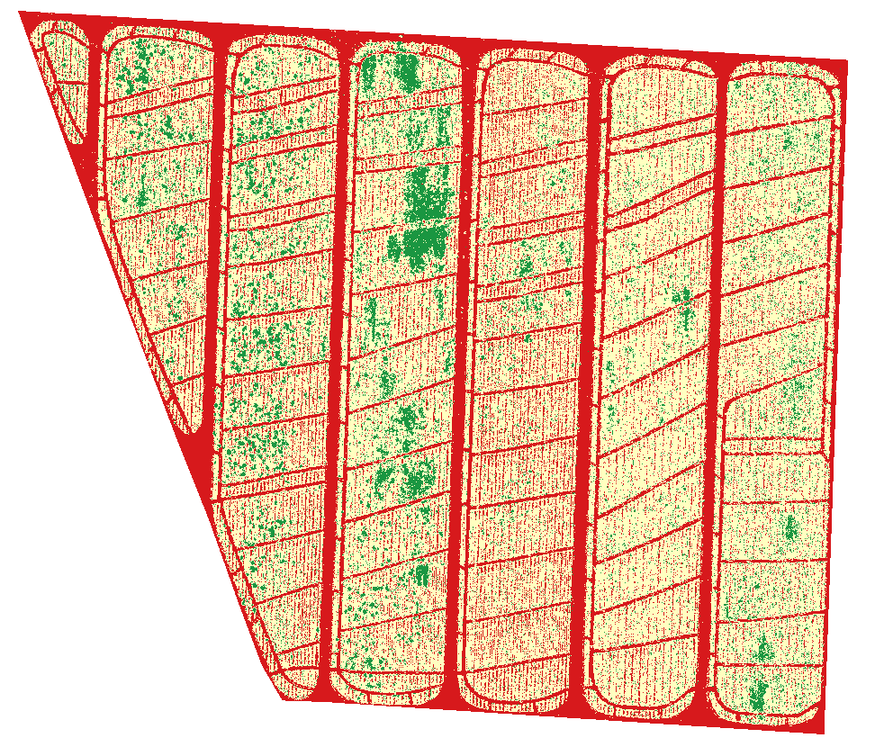